# Notebook

### Web Information Retrieval and Data Mining - Assignment 3

```
Student: KERKOC, MATIJA (1550446)
```

#### Answer 1.1, Baseline (4p)

- Dense network, at least 3 layers, shaped like a pyramid
  - Last layer: 10 nodes, sigmoid.
  - Loss: categorical cross-entropy. Metric: accuracy
- No preprocessing, regularization. Get at least 70% accuracy.
- Explain design decisions. Discuss performance.
  - Does it overfit (large/growing gap between loss and val_loss)?

[output not shown]

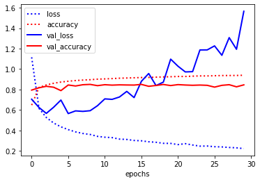

```
Model: "sequential_11"
_________________________________________________________________
Layer (type)                 Output Shape              Param #
=================================================================
conv2d_2 (Conv2D)            (None, 30, 30, 32)        896
_________________________________________________________________
flatten_6 (Flatten)          (None, 28800)             0
_________________________________________________________________
dense_40 (Dense)             (None, 128)               3686528
_________________________________________________________________
dense_41 (Dense)             (None, 64)                8256
_________________________________________________________________
dense_42 (Dense)             (None, 32)                2080
_________________________________________________________________
dense_43 (Dense)             (None, 10)                330
=================================================================
Total params: 3,698,090
Trainable params: 3,698,090
Non-trainable params: 0
_________________________________________________________________
None
def build_model_1_1():
  "Function that builds a model with 3 pyramid-shaped dense layers. No regularization or preprocessing yet."

  # Construct a model and add the 3 dense layers (+ input and output layer)
  model_1_1 = models.Sequential()
  model_1_1.add(layers.Conv2D(32, (3, 3), activation='relu', input_shape=(32, 32, 3)))
  model_1_1.add(layers.Flatten())
  model_1_1.add(layers.Dense(128, activation='relu'))
  model_1_1.add(layers.Dense(64, activation='relu'))
  model_1_1.add(layers.Dense(32, activation='relu'))
  model_1_1.add(layers.Dense(10, activation='softmax'))

  # Now we compile our model
  model_1_1.compile(optimizer='rmsprop',
              loss='categorical_crossentropy',
              metrics=['accuracy'])

  return model_1_1
```

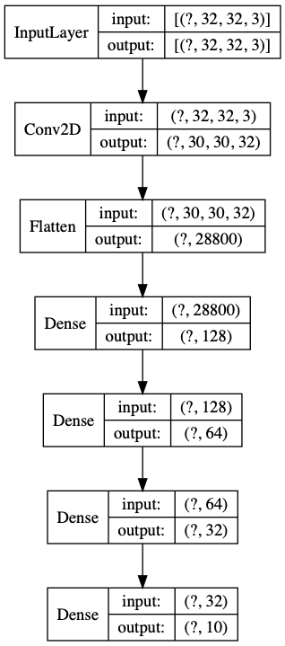

#### Answer 1.2, Preprocess (2p)

- Convert images to greyscale, other preprocessing optional.
  - Input shape should be (32,32,1)
- Explain design decisions. Is it better? Why (not)?
  - Color information is likely not so useful for classification. Greyscale makes the network smaller, less parameters to learn, less likely to overfit.

[output not shown]

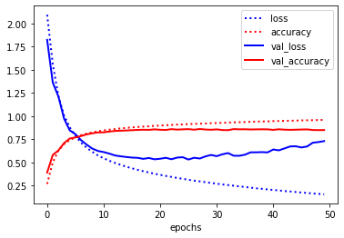

```
Model: "sequential_1"
_________________________________________________________________
Layer (type)                 Output Shape              Param #
=================================================================
conv2d_1 (Conv2D)            (None, 30, 30, 32)        320
_________________________________________________________________
flatten_1 (Flatten)          (None, 28800)             0
_________________________________________________________________
dense_4 (Dense)              (None, 128)               3686528
_________________________________________________________________
dense_5 (Dense)              (None, 64)                8256
_________________________________________________________________
dense_6 (Dense)              (None, 32)                2080
_________________________________________________________________
dense_7 (Dense)              (None, 10)                330
=================================================================
Total params: 3,697,514
Trainable params: 3,697,514
Non-trainable params: 0
_________________________________________________________________
None
def build_model_1_2():
  # Construct a model and add the layers
  model_1_2 = models.Sequential()
  model_1_2.add(layers.Conv2D(32, (3, 3), activation='relu', input_shape=(32, 32, 1)))
  model_1_2.add(layers.Flatten())
  model_1_2.add(layers.Dense(128, activation='relu'))
  model_1_2.add(layers.Dense(64, activation='relu'))
  model_1_2.add(layers.Dense(32, activation='relu'))
  model_1_2.add(layers.Dense(10, activation='softmax'))

  # Now we compile our model
  model_1_2.compile(loss='categorical_crossentropy',
              optimizer=optimizers.RMSprop(lr=1e-4),
              metrics=['accuracy'])

  return model_1_2
```

#### Answer 1.3, Tune (4p)

- Regularize the model. What works best?
  - Should consider batch normalization, dropout, l1/l2 regularization (or Nesterov)
- Tune other hyperparameters (e.g. learning rate, batch size,...) as you see fit.
  - At least consider tuning learning rate, ideally also momentum, decay, other optimizers
- Explain your findings and final design decisions. Discuss the results.
  - Should be better, at least it shouldn't overfit

[output not shown]

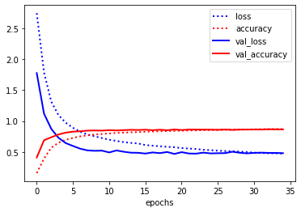

```
def build_model_1_3():
  # Construct a model and add the layers
  model_1_3 = models.Sequential()
  model_1_3.add(layers.Conv2D(32, (3, 3), activation='relu', input_shape=(32, 32, 1)))
  model_1_3.add(layers.Flatten())
  model_1_3.add(layers.Dense(128, activation='relu'))
  model_1_3.add(layers.BatchNormalization())
  model_1_3.add(layers.Dropout(0.3))
  model_1_3.add(layers.Dense(64, activation='relu'))
  model_1_3.add(layers.BatchNormalization())
  model_1_3.add(layers.Dropout(0.4))
  model_1_3.add(layers.Dense(32, activation='relu'))
  model_1_3.add(layers.BatchNormalization())
  model_1_3.add(layers.Dropout(0.5))
  model_1_3.add(layers.Dense(10, activation='softmax'))

  # Now we compile our model
  model_1_3.compile(loss='categorical_crossentropy',
              optimizer=optimizers.RMSprop(lr=1e-4),
              metrics=['accuracy'])

  return model_1_3
```

#### Answer 2.1, ConvNet (7p)

- Build a sequential ConvNet, get at least 90% accuracy.
  - Conv2D layers, input shape (32,32,1)
  - Consider using blocks of Conv2D layers with maxpooling in between
  - Use zero-padding in Conv2D layers because the images are small
  - At least one dense hidden layer and dense output layer (sigmoid)
  - Consider adding batch normalization, dropout
  - Consider small dropout rates in beginning, larger dropout rates later in network
  - Consider other optimizers and tuning learning rate, momentum,...
- Explain what you did and why (800 chars). Is it working well?
  - Should be quite elaborate and sensible

[output not shown]

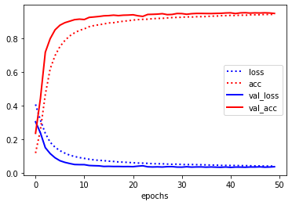

```
Model: "sequential_3"
_________________________________________________________________
Layer (type)                 Output Shape              Param #
=================================================================
conv2d_3 (Conv2D)            (None, 32, 32, 32)        320
_________________________________________________________________
batch_normalization_4 (Batch (None, 32, 32, 32)        128
_________________________________________________________________
conv2d_4 (Conv2D)            (None, 32, 32, 32)        9248
_________________________________________________________________
batch_normalization_5 (Batch (None, 32, 32, 32)        128
_________________________________________________________________
max_pooling2d_1 (MaxPooling2 (None, 16, 16, 32)        0
_________________________________________________________________
dropout_4 (Dropout)          (None, 16, 16, 32)        0
_________________________________________________________________
conv2d_5 (Conv2D)            (None, 16, 16, 64)        18496
_________________________________________________________________
batch_normalization_6 (Batch (None, 16, 16, 64)        256
_________________________________________________________________
conv2d_6 (Conv2D)            (None, 16, 16, 64)        36928
_________________________________________________________________
batch_normalization_7 (Batch (None, 16, 16, 64)        256
_________________________________________________________________
max_pooling2d_2 (MaxPooling2 (None, 8, 8, 64)          0
_________________________________________________________________
dropout_5 (Dropout)          (None, 8, 8, 64)          0
_________________________________________________________________
conv2d_7 (Conv2D)            (None, 8, 8, 128)         73856
_________________________________________________________________
batch_normalization_8 (Batch (None, 8, 8, 128)         512
_________________________________________________________________
conv2d_8 (Conv2D)            (None, 8, 8, 128)         147584
_________________________________________________________________
batch_normalization_9 (Batch (None, 8, 8, 128)         512
_________________________________________________________________
max_pooling2d_3 (MaxPooling2 (None, 4, 4, 128)         0
_________________________________________________________________
dropout_6 (Dropout)          (None, 4, 4, 128)         0
_________________________________________________________________
```

[output cut: 51 more lines]

```
  model_2_1.add(layers.BatchNormalization())
  model_2_1.add(layers.Dropout(0.5))
  model_2_1.add(layers.Dense(64, activation='relu'))
  model_2_1.add(layers.BatchNormalization())
  model_2_1.add(layers.Dropout(0.5))
  model_2_1.add(layers.Dense(32, activation='relu'))
  model_2_1.add(layers.BatchNormalization())
  model_2_1.add(layers.Dropout(0.5))
  model_2_1.add(layers.Dense(10, activation='softmax'))

  # Now we compile our model
  model_2_1.compile(loss='binary_crossentropy',
              optimizer=optimizers.RMSprop(lr=1e-4),
              metrics=['acc'])
  return model_2_1
```

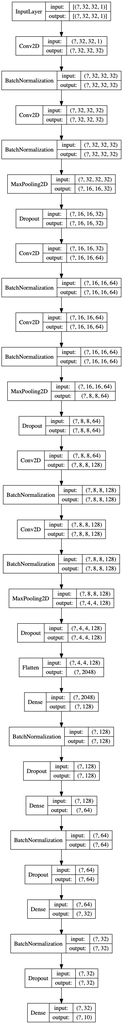

#### Answer 2.2, Data Augmentation (3p)

- Augment the preprocessed training data.
  - Use small variations (small shifts up-down, left-right) of flips becasue the images are small
  - Large shifts and rotations distort the image too much
- Explain what you did and why. Discuss the performance of the model.

[output not shown]

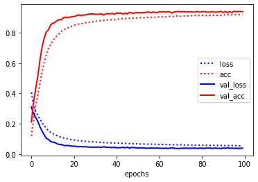

```
transformations = ImageDataGenerator(
    height_shift_range=0.1,
    shear_range=0.1,
    horizontal_flip=False,
    vertical_flip=True,
    fill_mode='nearest'
)
```

#### Answer 3.1, Misclassifications (2p)

[output not shown]

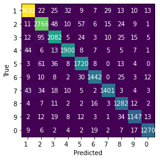

[figure not shown]

```
__________________________________________________________________________
Now plot the misclassifications for class 7.
Images predicted as 1, but are true 7:
```

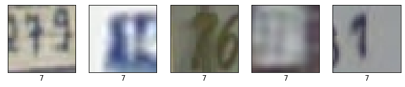

```
Obvious mistakes. 7s are just rotated and they look like 1s.
__________________________________________________________________________
Images predicted as 2, but are true 7:
```

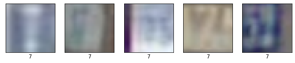

```
Pretty obvious. 7s are without middle line and have rounded upper corner,
so with a little noise on the lower part, they look like 2s.
__________________________________________________________________________
Images predicted as 3, but are true 7:
```

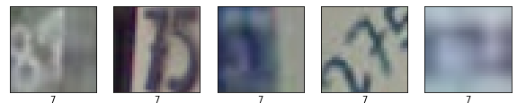

```
Again we can see 7s with middle line and rounded top, might look like 3s.
__________________________________________________________________________
Images predicted as 4, but are true 7:
```

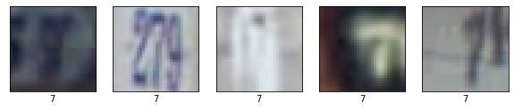

```
Again pretty obvious. 7s with middle line, might look like 4s.
__________________________________________________________________________
Images predicted as 5, but are true 7:
```

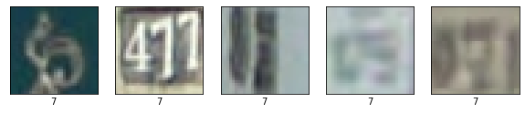

[output not shown]

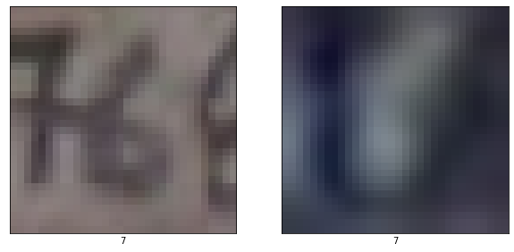

```
Interesting! Looks like, that both mistakes are there also 6s beside the 7s.
Looks like, that model payed attention to that part of picture.
__________________________________________________________________________
Images predicted as 8, but are true 7:
```

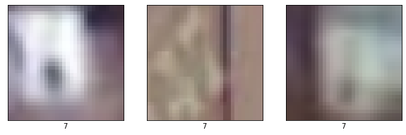

```
Ugh! Too noisy, impossible to see anything.
__________________________________________________________________________
Images predicted as 9, but are true 7:
```

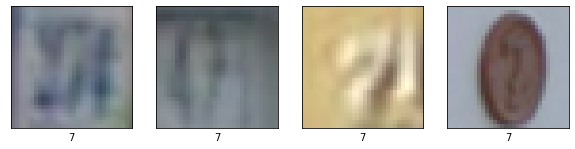

```
Well, 7s with allongated top line might look like 9s in some cases.
__________________________________________________________________________
Images predicted as 0, but are true 7:
```

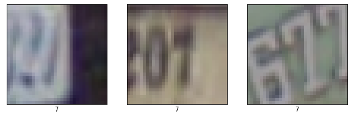

```
There is probably 0 alongside 7 on the picture.
__________________________________________________________________________
```

#### Answer 3.2, Activations (4p)

- Retrieve and visualize the activations for one example
- For every filter for different convolutional layers (at different depths in the network).
- Give an explanation. Is your model indeed learning something useful?
  - Should detect edges etc in first layers, higher-order object (e.g. interesting regions) in deeper layers.

[output not shown]

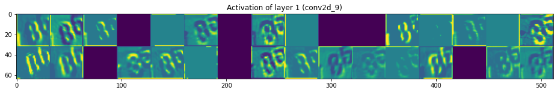

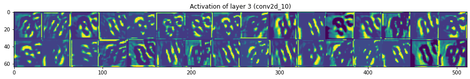

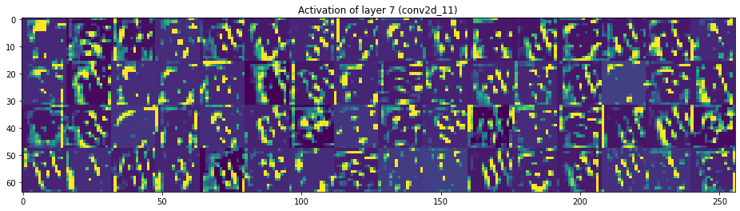

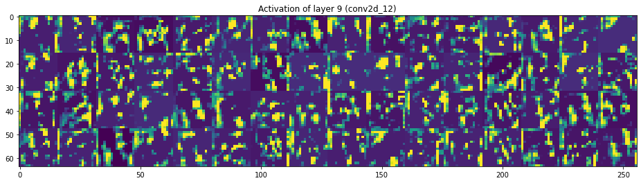

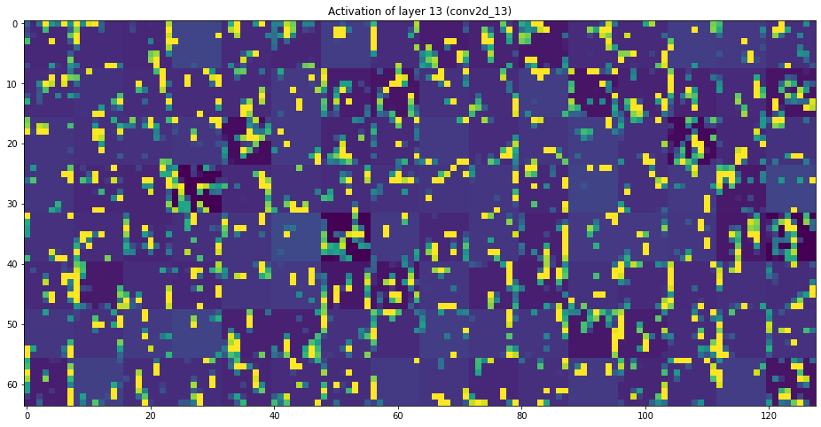

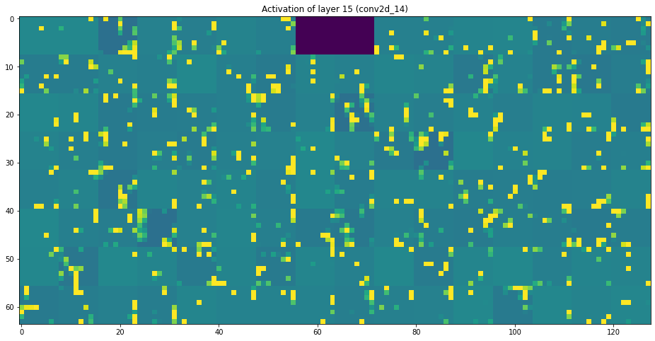

#### Answer 3.3, Class activation map (4p)

- Show a class activation map for your last convolutional layer
- Superimpose the activation map over the image, or plot side by side
  - Should make sense, detect interesting regions to classify the number

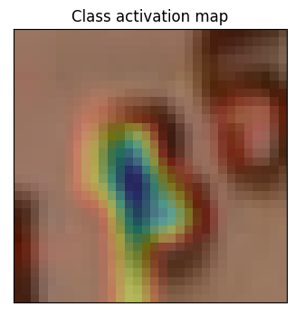

[output not shown]

[output cut: 26 more lines]

[output not shown]

#### Answer 4.1, Fast feature extraction (5p)

- Import the VGG16 model, pretrained on ImageNet
- Freeze convolutional base, adds a dense layer
- Consider unfreezing the last few convolutional layers and evaluate whether that works better
  - Check if they do. It is very likely to help.
- Discuss the observed performance
  - Should get around 80% accuracy

[output not shown]

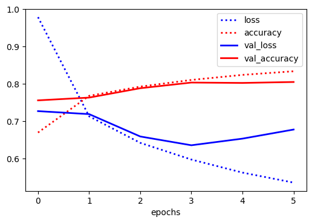

```
Model: "sequential_4"
_________________________________________________________________
Layer (type)                 Output Shape              Param #
=================================================================
vgg16 (Model)                (None, 1, 1, 512)         14714688
_________________________________________________________________
flatten_4 (Flatten)          (None, 512)               0
_________________________________________________________________
dense_16 (Dense)             (None, 1024)              525312
_________________________________________________________________
dense_17 (Dense)             (None, 10)                10250
=================================================================
Total params: 15,250,250
Trainable params: 7,614,986
Non-trainable params: 7,635,264
_________________________________________________________________
None
def build_model_4_1():
  VGG16_model = VGG16(include_top=False, weights='imagenet', input_shape=(32, 32, 3))
  model_4_1 = models.Sequential()
  # Only include convolutional layers
  model_4_1.add(VGG16_model)
  for layer in VGG16_model.layers[:-4]:
    layer.trainable = False

  # Sanity check of freezenes
  for layer in VGG16_model.layers:
    print(layer,'Trainable:', layer.trainable)

  # Add dense layer
  model_4_1.add(layers.Flatten())
  model_4_1.add(layers.Dense(1024, activation='relu'))

  model_4_1.add(layers.Dense(10, activation='softmax'))

  # Compile
  model_4_1.compile(loss='categorical_crossentropy',
              optimizer=optimizers.RMSprop(lr=1e-4),
              metrics=['accuracy'])

  return model_4_1
```

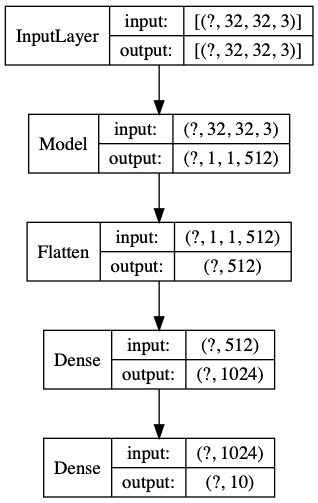

#### Answer 4.2, Embeddings (5p)

- Generate embeddings with the trained convolutional part of model_4_1 (without the dense layer)
- Embed the training and test data and store them to disk
- Build and evaluate a pipeline on the embedded data
  - Check if pipeline makes sense (e.g. use models that can handle many dimensions)
- Describe what you did and what you observed (max 800 chars).
  - Consider different models, preprocessing, tuning, etc.
  - Check performance (see original Submission.html) when in doubt. We did not run all the evaluations because it takes too long, and the output is ill-defined.

[output not shown]

```
Running time: 45.40 seconds
Last modified: May 26, 2020
scikit-learn version: 0.23.1
```